# Construction of the LHT categorization framework

MGH

2026-07-30

In this document, I present the work done to validate the robustness of the species coordinates in the life-history traits variation plane composed of the Fast-Slow (FS) and the Reproductive Strategies (RS) continua (see Table S1 for a short review on the subject). This was used to build the LHT categorization framework.

We used the published results from Capdevila et al. 2020 (https://doi.org/10.1111/1365-2435.13604) and in particular, the data and code from this publication available at Dryad (https://datadryad.org/dataset/doi:10.5061/dryad.cvdncjt1q). It represents the most comprehensive published LHT multivariate analysis including 807 terrestrial and aquatic plant and animal species. Briefly, two databases COMPADRE/COMADRE (Salguero-Gomez et al. 2015, 2016; https://compadre-db.org) were used by the authors to estimate 6 LHTs in these species and from which a Principal Component Analysis (PCA) was performed.

The main steps we followed were (as presented below):  
- Validating the robustness of phylogenetic corrections and missing data imputation by repeating PCAs without phylogenetic correction and without imputed data  
- Comparison of species coordinates between two studies (Capdevila et al. 2020 and Paniw et al. 2018 with 458 species)  
We thank Rob Salguero-Gomez for sharing with us coordinates of the species in the original PCA from Capdevila et al. 2020.

Finally, we were able to define a small number of LHT categories across the LHT variation plane.

# 1 Set-up

```r
library(anyLib)
anyLib(c("dplyr","tidyverse","ggplot2","plotly","FactoMineR","factoextra","GGally","sf","ggrepel"))
```

```
##      dplyr  tidyverse    ggplot2     plotly FactoMineR factoextra     GGally
##       TRUE       TRUE       TRUE       TRUE       TRUE       TRUE       TRUE
##         sf    ggrepel
##       TRUE       TRUE
```

```r
#set-up for the graphics that will be useful
colors_OrgType <- c(
  "Algae" = "#86CE00FF",
  "Annual" = "#F6F926FF",
  "Epiphyte" = "#FC6955FF",
  "Herbaceous perennial" = "#1CA71CFF",
  "Palm" = "#B68100FF",
  "Shrub" = "#6E899CFF",
  "Succulent" = "#EEA6FBFF",
  "Tree" = "#FB0D0DFF",
  "Fish" = "#2E91E5FF",
  "Amphibian" = "#E3EE9EFF",
  "Other invertebrates" = "#C9FBE5FF",
  "Aves" = "#FE00CEFF",
  "Crustacean" = "orange",
  "Insecta" = "#FC0080FF",
  "Mammalia" = "#0D2A63FF",
  "Reptilia" = "#00A08BFF",
  "Thaliacea" = "#FED4C4FF")

shape_OrgType <- c(
  #for points shape according organism type
    "Algae" = 10,
  "Annual" = 17,
  "Epiphyte" = 12,
  "Herbaceous perennial" = 19,
  "Palm" = 14,
  "Shrub" = 15,
  "Succulent" = 16,
  "Tree" = 17,
  "Fish" = 18,
  "Amphibian" = 19,
  "Other invertebrates" = 19,
  "Aves" = 15,
  "Crustacean" = 22,
  "Insecta" = 23,
  "Mammalia" = 24,
  "Reptilia" = 6,
  "Thaliacea" = 10
)
```

List of the Life-History Traits studied in Capdevila et al. (2020):  
- GenT = Generation time  
- Surv_H = Rate of senescence (survival)  
- Age_mat_La = Age at maturity  
- Growth = Mean vital rate of progressive growth  
- Repro = Mean vital rate of sexual reproduction  
- Degr_itero_S = Degree of iteroparity

```r
LHT <- c("GenT","Surv_H","Age_mat_La","Growth","Repro","Degr_itero_S")
```

# 2 Explore Capdevila PCA results

To explore the results of this PCA from Capdevila et al. 2020, let’s add some information to the table, in particular about the species and the original Matrices Population Model (MPM) used to calculate the LHTs.

For that, I will use the COMPADRE/COMADRE databases relating the references of the studies to obtain the MPM of the different species and related metadata.

```r
#Capdevila et al. 2020 - 807 plants and animals
Capdevila_2020_pl_ani <- read.csv("SalgoTeam_data/Capdevila&_2020_Phylo PCA scores.csv")
colnames(Capdevila_2020_pl_ani)[1] <- "Species"
```

This dataset was kindly provided by Rob Salguero-Gómez upon request in 2024.

## 2.1 Add complementary info about species using COMPADRE/COMADRE databases

Let’s load the COMPADRE/COMADRE databases to get the information we need. I use the same versions as the ones used in Capdevila et al. (2020).

```r
library(Rcompadre)
#same versions as in the article
compadre <- cdb_fetch("compadre", version="5.0.1")
```

```
## This is COMPADRE version 5.0.0 (release date Jun_06_2019)
## See user agreement at https://compadre-db.org/Help/UserAgreement
## See how to cite with `citation(Rcompadre)`
```

```r
comadre <- cdb_fetch("comadre", version="3.0.1")
```

```
## This is COMADRE version 3.0.0 (release date Jun_06_2019)
## See user agreement at https://compadre-db.org/Help/UserAgreement
## See how to cite with `citation(Rcompadre)`
```

Example of information for one species from the database:

```r
# subset to the species 'Echinacea angustifolia'
as.data.frame(filter(compadre, SpeciesAccepted == "Echinacea angustifolia"))
```

| mat | SpeciesAuthor | SpeciesAccepted | CommonName | Genus | Family | Order | Class | Phylum | Kingdom | OrganismType | DicotMonoc | AngioGymno | Authors | Journal | YearPublication | DOI.ISBN | AdditionalSource | StudyDuration | StudyStart | StudyEnd | ProjectionInterval | NumberPopulations | MatrixCriteriaSize | MatrixCriteriaOntogeny | MatrixCriteriaAge | MatrixPopulation | Lat | Lon | Altitude | … |
| --- | --- | --- | --- | --- | --- | --- | --- | --- | --- | --- | --- | --- | --- | --- | --- | --- | --- | --- | --- | --- | --- | --- | --- | --- | --- | --- | --- | --- | --- | --- |
|  | Echinacea_angustifolia | Echinacea angustifolia | Narrow-leaved purple coneflower | Echinacea | Compositae | Asterales | Magnoliopsida | Magnoliophyta | Plantae | Herbaceous perennial | Eudicot | Angiosperm | Dalgleish; Koons; Adler | J Ecol | 2010 | 10.1111/j.1365-2745.2009.01585.x | Dalgleish J Ecol 2010 Appendix.zip | 33 | 1939 | 1971 | 1 | 1 | No | No | Yes | Hays | 38.13333 | -99.05000 | 627 | … |
|  | Echinacea_angustifolia | Echinacea angustifolia | Narrow-leaved purple coneflower | Echinacea | Compositae | Asterales | Magnoliopsida | Magnoliophyta | Plantae | Herbaceous perennial | Eudicot | Angiosperm | Dalgleish; Koons; Adler | J Ecol | 2010 | 10.1111/j.1365-2745.2009.01585.x | Dalgleish J Ecol 2010 Appendix.zip | 33 | 1939 | 1971 | 1 | 1 | No | No | Yes | Hays | 38.13333 | -99.05000 | 627 | … |
|  | Echinacea_angustifolia | Echinacea angustifolia | Narrow-leaved purple coneflower | Echinacea | Compositae | Asterales | Magnoliopsida | Magnoliophyta | Plantae | Herbaceous perennial | Eudicot | Angiosperm | Dalgleish; Koons; Adler | J Ecol | 2010 | 10.1111/j.1365-2745.2009.01585.x | Dalgleish J Ecol 2010 Appendix.zip | 33 | 1939 | 1971 | 1 | 1 | No | No | Yes | Hays | 38.13333 | -99.05000 | 627 | … |
|  | Echinacea_angustifolia | Echinacea angustifolia | Narrow-leaved purple coneflower | Echinacea | Compositae | Asterales | Magnoliopsida | Magnoliophyta | Plantae | Herbaceous perennial | Eudicot | Angiosperm | Dalgleish; Koons; Adler | J Ecol | 2010 | 10.1111/j.1365-2745.2009.01585.x | Dalgleish J Ecol 2010 Appendix.zip | 33 | 1939 | 1971 | 1 | 1 | No | No | Yes | Hays | 38.13333 | -99.05000 | 627 | … |
|  | Echinacea_angustifolia | Echinacea angustifolia | Narrow-leaved purple coneflower | Echinacea | Compositae | Asterales | Magnoliopsida | Magnoliophyta | Plantae | Herbaceous perennial | Eudicot | Angiosperm | Dalgleish; Koons; Adler | J Ecol | 2010 | 10.1111/j.1365-2745.2009.01585.x | Dalgleish J Ecol 2010 Appendix.zip | 33 | 1939 | 1971 | 1 | 1 | No | No | Yes | Hays | 38.13333 | -99.05000 | 627 | … |
|  | Echinacea_angustifolia | Echinacea angustifolia | Narrow-leaved purple coneflower | Echinacea | Compositae | Asterales | Magnoliopsida | Magnoliophyta | Plantae | Herbaceous perennial | Eudicot | Angiosperm | Dalgleish; Koons; Adler | J Ecol | 2010 | 10.1111/j.1365-2745.2009.01585.x | Dalgleish J Ecol 2010 Appendix.zip | 33 | 1939 | 1971 | 1 | 1 | No | No | Yes | Hays | 38.13333 | -99.05000 | 627 | … |
|  | Echinacea_angustifolia | Echinacea angustifolia | Narrow-leaved purple coneflower | Echinacea | Compositae | Asterales | Magnoliopsida | Magnoliophyta | Plantae | Herbaceous perennial | Eudicot | Angiosperm | Dalgleish; Koons; Adler | J Ecol | 2010 | 10.1111/j.1365-2745.2009.01585.x | Dalgleish J Ecol 2010 Appendix.zip | 33 | 1939 | 1971 | 1 | 1 | No | No | Yes | Hays | 38.13333 | -99.05000 | 627 | … |
|  | Echinacea_angustifolia | Echinacea angustifolia | Narrow-leaved purple coneflower | Echinacea | Compositae | Asterales | Magnoliopsida | Magnoliophyta | Plantae | Herbaceous perennial | Eudicot | Angiosperm | Dalgleish; Koons; Adler | J Ecol | 2010 | 10.1111/j.1365-2745.2009.01585.x | Dalgleish J Ecol 2010 Appendix.zip | 33 | 1939 | 1971 | 1 | 1 | No | No | Yes | Hays | 38.13333 | -99.05000 | 627 | … |
|  | Echinacea_angustifolia | Echinacea angustifolia | Narrow-leaved purple coneflower | Echinacea | Compositae | Asterales | Magnoliopsida | Magnoliophyta | Plantae | Herbaceous perennial | Eudicot | Angiosperm | Dalgleish; Koons; Adler | J Ecol | 2010 | 10.1111/j.1365-2745.2009.01585.x | Dalgleish J Ecol 2010 Appendix.zip | 33 | 1939 | 1971 | 1 | 1 | No | No | Yes | Hays | 38.13333 | -99.05000 | 627 | … |
|  | Echinacea_angustifolia | Echinacea angustifolia | Narrow-leaved purple coneflower | Echinacea | Compositae | Asterales | Magnoliopsida | Magnoliophyta | Plantae | Herbaceous perennial | Eudicot | Angiosperm | Dalgleish; Koons; Adler | J Ecol | 2010 | 10.1111/j.1365-2745.2009.01585.x | Dalgleish J Ecol 2010 Appendix.zip | 33 | 1939 | 1971 | 1 | 1 | No | No | Yes | Hays | 38.13333 | -99.05000 | 627 | … |

[output cut: 43 more lines]

Same thing in COMADRE as you can see here (corresponding database for animal species):

```r
as.data.frame(filter(comadre, SpeciesAccepted == "Canis lupus"))
```

| mat | SpeciesAuthor | SpeciesAccepted | CommonName | Genus | Family | Order | Class | Phylum | Kingdom | OrganismType | DicotMonoc | AngioGymno | Authors | Journal | YearPublication | DOI.ISBN | AdditionalSource | StudyDuration | StudyStart | StudyEnd | ProjectionInterval | NumberPopulations | MatrixCriteriaSize | MatrixCriteriaOntogeny | MatrixCriteriaAge | MatrixPopulation | Lat | Lon | Altitude | … |
| --- | --- | --- | --- | --- | --- | --- | --- | --- | --- | --- | --- | --- | --- | --- | --- | --- | --- | --- | --- | --- | --- | --- | --- | --- | --- | --- | --- | --- | --- | --- |
|  | Canis_lupus | Canis lupus | Grey wolf | Canis | Canidae | Carnivora | Mammalia | Chordata | Animalia | Mammalia | NA | NA | Chapron; Legendre; Ferrière; Clobert; Haight | C R Biol | 2003 | 10.1016/S1631-0691(03)00148-3 | van de Kerk 2012; R.G. Haight, L.D. Mech, Computer simulation of vasectomy for wolf control, J. Wildl. Manage. 61 (1997) 1023–1031; R.G. Haight, D.J. Mladenoff, A.P. Wydeven, Modeling disjunct gray wo… | NA | NA | NA | 1 | 5 | No | No | Yes | FRANK | NA | NA | NA | … |
|  | Canis_lupus_3 | Canis lupus | Grey wolf | Canis | Canidae | Carnivora | Mammalia | Chordata | Animalia | Mammalia | NA | NA | Miller; Jensen; Hammill | Ecol Model | 2002 | 10.1016/S0304-3800(01)00493-8 | van de Kerk 2013; Brongo Thesis 2002; | 10 | 1991 | 2000 | 1 | 1 | No | No | Yes | Upper Peninsula of Michigan | 46.53375 | -87.38453 | 228 | … |
|  | Canis_lupus_4 | Canis lupus | Grey wolf | Canis | Canidae | Carnivora | Mammalia | Chordata | Animalia | Mammalia | NA | NA | Carroll; Phillips; Schumaker; Smith | Cons Biol | 2003 | 10.1046/j.1523-1739.2003.01552.x | Naujokaitis-Lewis Cons Biol 2009 | NA | NA | NA | 1 | 1 | No | No | Yes | Southern Rocky Mountains | 39.00000 | -107.00000 | 2300 | … |
|  | Canis_lupus_4 | Canis lupus | Grey wolf | Canis | Canidae | Carnivora | Mammalia | Chordata | Animalia | Mammalia | NA | NA | Carroll; Phillips; Schumaker; Smith | Cons Biol | 2003 | 10.1046/j.1523-1739.2003.01552.x | Naujokaitis-Lewis Cons Biol 2009 | NA | NA | NA | 1 | 1 | No | No | Yes | Southern Rocky Mountains | 39.00000 | -107.00000 | 2300 | … |
|  | Canis_lupus_5 | Canis lupus | Gray wolf | Canis | Canidae | Carnivora | Mammalia | Chordata | Animalia | Mammalia | NA | NA | Cubaynes; MacNulty; Stahler; Quimby; Smith; Coulson | Popul Ecol | 2014 | 10.1111/1365-2656.12238 | NA | 13 | 1998 | 2010 | 1 | 2 | No | No | Yes | Yellowstone - NR & Interior | NA | NA | NA | … |

We will focus only on the species in Capdevila. With the Appendix S1 from Capdevila et al. - 2020 we can get the information of the population studied using their DOI.

```r
#Select only the species from Capdevila study
Species_Capdevila <- Capdevila_2020_pl_ani$Species
compadre_Capdevila <- filter(compadre@data, SpeciesAccepted %in% Species_Capdevila)
comadre_Capdevila <- filter(comadre@data, SpeciesAccepted %in% Species_Capdevila)

compadre_Capdevila <- compadre_Capdevila %>%
                          mutate(first_author= str_extract(Authors, "^[^;]+"))

comadre_Capdevila <- comadre_Capdevila %>%
                          mutate(first_author= str_extract(Authors, "^[^;]+"))

#Get the DOI info
Ref_Capdevila_2020 <- read.csv("SalgoTeam_data/Capdevila&_2020_suppl_fec13604-sup-0003-tables1.csv", fileEncoding = "Latin1") #encoding to avoid unread characters
Ref_Capdevila_2020 <- Ref_Capdevila_2020 %>%
                          mutate(doi= str_extract(citation, "(?<=doi:)[\\d.\\/\\w-]+"),
                                 author= str_extract(citation, "^[^,]+"))

#select only the corresponding study
compadre_Capdevila <- compadre_Capdevila %>%
                          filter(DOI.ISBN %in% Ref_Capdevila_2020$doi |
                                 tolower(first_author) %in% tolower(Ref_Capdevila_2020$author))

comadre_Capdevila <- comadre_Capdevila %>%
                          filter(DOI.ISBN %in% Ref_Capdevila_2020$doi |
                                 tolower(first_author) %in% tolower(Ref_Capdevila_2020$author))

#cleaning
rm(comadre, compadre, Species_Capdevila)
```

To check if the matching of the two tables seems okay:

```
## [1] "For COMPADRE = Plants"
```

```
## [1] "Nb of species in Capdevila study"
```

```
## [1] 560
```

```
## [1] "Matching with the database"
```

```
## [1] 507
```

```
## [1] "For COMADRE = Animals"
```

```
## [1] "in Capdevila study"
```

```
## [1] 240
```

```
## [1] "Matching with the database"
```

```
## [1] 200
```

This difference can be explained by references or matrices removed between 2020 and 2024 from the database.

I am now going to gather some metadata from COMADRE/COMPADRE that will be useful for the next steps and make a single table for plants and animals.

```r
Info_recap_Capdevila_pop_geo <- as.data.frame(compadre_Capdevila) %>%
                                  select(SpeciesAccepted,Kingdom,OrganismType,YearPublication,StudyDuration,
                                         NumberPopulations,Lat,Lon,Country,Continent) %>%
                                  mutate(Database = "COMPADRE")

Info_recap_Capdevila_pop_geo <- rbind(Info_recap_Capdevila_pop_geo,
                                      as.data.frame(comadre_Capdevila) %>%
                                  select(SpeciesAccepted,Kingdom,OrganismType,YearPublication,StudyDuration,
                                         NumberPopulations,Lat,Lon,Country,Continent)%>%
                                  mutate(Database = "COMADRE"))

Info_recap_Capdevila_pop_geo <- Info_recap_Capdevila_pop_geo %>%
                                      distinct(SpeciesAccepted,Kingdom,OrganismType,YearPublication,StudyDuration,
                                         NumberPopulations,Lat,Lon,Country,Continent)

Info_recap_Capdevila_pop_geo
```

| SpeciesAccepted | Kingdom | OrganismType | YearPublication | StudyDuration | NumberPopulations | Lat | Lon | Country | Continent |
| --- | --- | --- | --- | --- | --- | --- | --- | --- | --- |
| Alaria nana | Chromalveolata | Algae | 2005 | 5 | 1 | 48.3841389 | -124.7336389 | USA | N America |
| Ascophyllum nodosum | Chromalveolata | Algae | 2014 | 5 | NA | 41.6846944 | -8.8502222 | PRT | Europe |
| Ascophyllum nodosum | Chromalveolata | Algae | 2014 | 5 | NA | NA | NA | FRA | Europe |
| Ecklonia radiata | Chromalveolata | Algae | 2001 | 4 | 4 | NA | NA | NZL | Oceania |
| Ecklonia radiata | Chromalveolata | Algae | 2001 | 4 | 4 | -43.8170000 | 172.7502778 | NZL | Oceania |
| Ecklonia radiata | Chromalveolata | Algae | 2001 | 4 | 4 | -43.8500000 | 172.7513889 | NZL | Oceania |
| Fucus vesiculosus | Chromalveolata | Algae | 1993 | 5 | 1 | 49.2833333 | -123.1166667 | CAN | N America |
| Fucus serratus | Chromalveolata | Algae | 2014 | 5 | NA | NA | NA | PRT | Europe |
| Fucus serratus | Chromalveolata | Algae | 2014 | 5 | NA | NA | NA | FRA | Europe |
| Gelidium sesquipedale | Plantae | Algae | 1998 | 3 | 1 | 38.4014444 | -9.2172778 | PRT | Europe |

[output cut: 1182 more lines]

```r
#modify a column name
Info_recap_Capdevila_pop_geo <- Info_recap_Capdevila_pop_geo %>%
                                    rename(Species=SpeciesAccepted)

#join tables with PCA and info about population and species characteristics
Infos_species_Capdevila <- left_join(Capdevila_2020_pl_ani,
                                     Info_recap_Capdevila_pop_geo %>%
                                        distinct(Species, .keep_all = TRUE) %>%
                                        select(Species, Kingdom, OrganismType, Country, Continent),
                                     by="Species")
```

There are a little too many categories (25) for the organism types so let’s try to gather some categories together.

```r
OrganismType <- unique(Infos_species_Capdevila$OrganismType)

OrganismType_cat <- data.frame(OrganismType=OrganismType)


OrganismType_cat <- OrganismType_cat %>%
  mutate(OrganismType2 = case_when(
    OrganismType == "Amphibia" | OrganismType == "Amphibian" ~ "Amphibian",
    OrganismType == "Malacostraca" | OrganismType == "Branchiopoda" | OrganismType == "Maxillopoda" ~ "Crustacean",
    OrganismType == "Actinopterygii" | OrganismType == "Elasmobranchii" ~ "Fish",
    OrganismType == "Bivalvia" | OrganismType == "Gastropoda" | OrganismType == "Clitellata" | OrganismType == "Anthozoa" | OrganismType == "Demospongiae" | OrganismType == "Echinoidea" ~ "Other invertebrates",
    TRUE ~ OrganismType
  ))

#Let's add this info in our dataset
Infos_species_Capdevila <- Infos_species_Capdevila %>%
  left_join(OrganismType_cat, by = "OrganismType")

rm(OrganismType_cat)
```

I now have 17 organism types. Note that for some species, there is no data about the organism type.

## 2.2 Plot species according to the organism type

The species coordinates used here are from Capdevila et al. (2020; see their Figure 2).

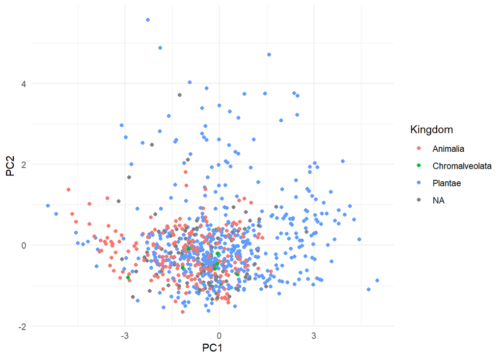

```r
#color for Kingdom
ggplot(Infos_species_Capdevila, aes(x=PC1, y=PC2, color=Kingdom, fill=Kingdom))+
  geom_point()+
  theme_minimal()
```

```r
#color and shape for Organism type
i <- ggplot(Infos_species_Capdevila, aes(x=PC1, y=PC2, color=OrganismType2, shape=OrganismType2, label=Species))+
  geom_point()+
  scale_color_manual(values=colors_OrgType, na.value = "grey")+
  scale_shape_manual(values=shape_OrgType, na.value = 18)+
  theme_minimal()
ggplotly(i)
```

[interactive chart not shown]

Note that these results are obtained from the mean PCA of 10 imputed datasets and with a phylogenetic correction.

# 3 Impact of phylogenetic correction and imputation on the species coordinates

**We want to understand the impact of imputation and phylogenetical correction in phylogenetically-informed PCA for both traits loadings and for species coordinates in the PC1-PC2 plane. I will rerun PCAs from both raw LHT data and imputed data.**

## 3.1 PCA with unimputed data

### 3.1.1 Imputation of LHT data in the Capdevila et al. study

```r
Capdevila_raw_LHT_data <- read.csv("SalgoTeam_data/lifeHistoryData.csv",sep=";")
Capdevila_raw_LHT_data <- Capdevila_raw_LHT_data %>%
                              rename(Species=sp,
                                     Surv_H=H,
                                     Age_mat_La=La,
                                     Growth=GrowSSD,
                                     Repro=RepSSD,
                                     Degr_itero_S=S)

Capdevila_raw_LHT_data <- left_join(Capdevila_raw_LHT_data,
                                    Infos_species_Capdevila %>%
                                      select(Species,  OrganismType2),
                                    by="Species")


# dataset with missing data
missing_data <- Capdevila_raw_LHT_data %>%
                    filter(rowSums(is.na(select(.,LHT)))>0)
Infos_species_Capdevila <- Infos_species_Capdevila %>%
                              mutate(Imputation =
                                       case_when(Species %in% missing_data$Species ~ "Yes",
                                                 TRUE ~ "No"))
```

```
## [1] "How many species with no data at all? - ie. with fully imputed data"
```

```
## [1] 140
```

```
## [1] "How many species with more than 1 LHT with no data?"
```

```
## [1] 254
```

Spread of species with imputed data and their coordinates in the PC1-2 plane:

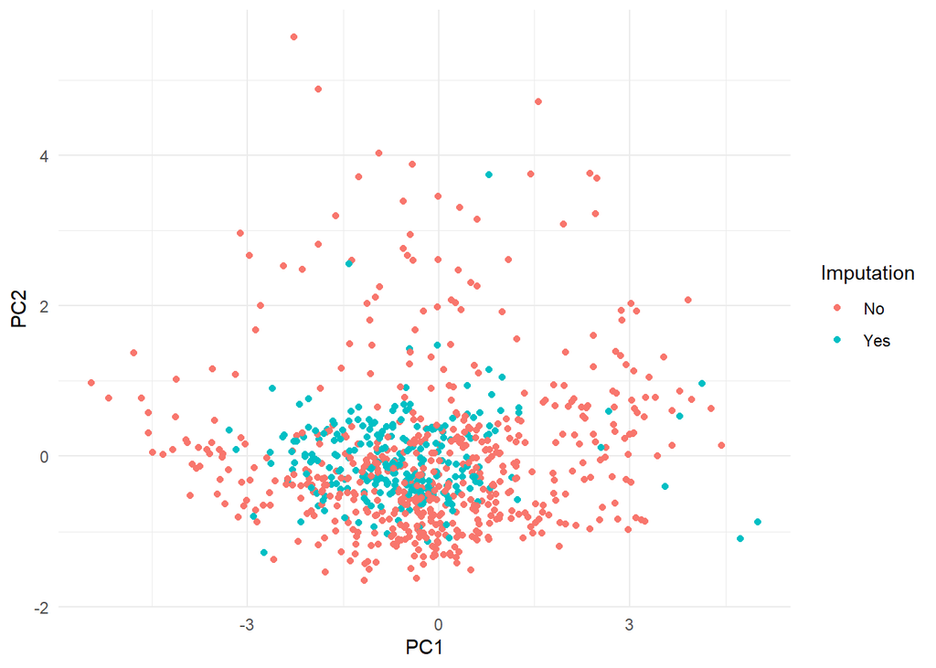

```r
ggplot(Infos_species_Capdevila, aes(x=PC1, y=PC2, color=Imputation, fill=Imputation))+
  geom_point()+
  theme_minimal()
```

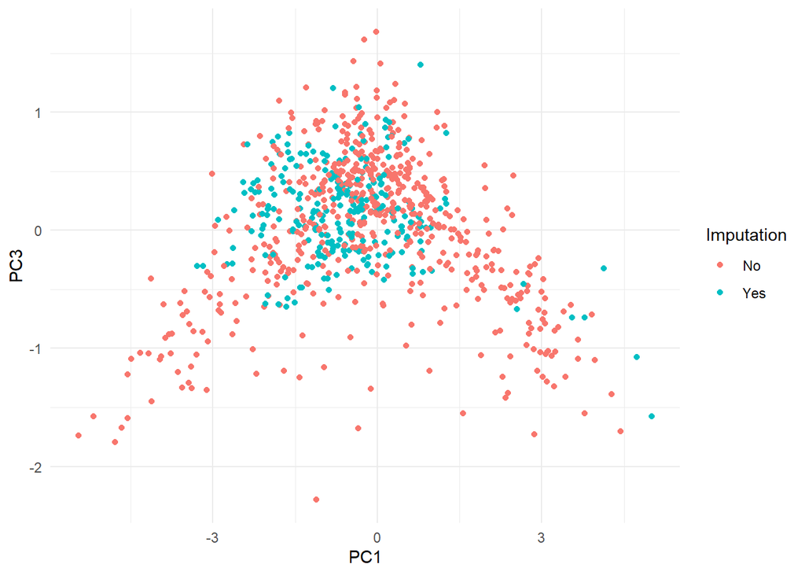

```r
ggplot(Infos_species_Capdevila, aes(x=PC1, y=PC3, color=Imputation, fill=Imputation))+
  geom_point()+
  theme_minimal()
```

Imputed data is less widespread than non imputed data. Seems logical but still worth to check results with and without imputed data.

(see Appendix S2: Extended methods from Capdevila et al. (2020) for more details and explanations about the imputation method).

What is the organism type of species with imputed data?

```r
p <- Infos_species_Capdevila %>% filter(Imputation=="Yes") %>%
      ggplot(aes(x=PC1, y=PC2, shape=OrganismType, color=OrganismType, label=Species))+
        geom_point()+
        theme_minimal()+
        scale_color_manual(values=colors_OrgType, na.value = "grey")+
        scale_shape_manual(values=shape_OrgType, na.value = 18)+
        xlim(-6,6)+ylim(-2,6)
ggplotly(p)
```

[interactive chart not shown]

Imputation does not seem specific to an organism type.

### 3.1.2 Transformation of raw LHT data in species with limited imputation

```r
non_missing_raw_data <- Capdevila_raw_LHT_data %>%
                  filter(!Species %in% missing_data$Species)

head(non_missing_raw_data)
```

|  | Species | GenT | Surv_H | Age_mat_La | Growth | Repro | Degr_itero_S | R | Kingdom | Sessi | OrganismType2 |
| --- | --- | --- | --- | --- | --- | --- | --- | --- | --- | --- | --- |
| 1 | Abies concolor | 42.49105 | 1.239088 | 23.000488 | 0.05531173 | 0.01618037 | 0.3196522 | Terrestrial | Plantae | Sessile | Tree |
| 2 | Abies magnifica | 43.93283 | 1.141076 | 24.367043 | 0.05374454 | 0.01457537 | 0.5293845 | Terrestrial | Plantae | Sessile | Tree |
| 3 | Abies sachalinensis | 17.29990 | 0.906790 | 9.412318 | 0.05703345 | 0.02187056 | 1.1064068 | Terrestrial | Plantae | Sessile | Tree |
| 4 | Acer palmatum | 225.15076 | 2.137124 | 135.048141 | 0.05130598 | 0.05131870 | 1.7390858 | Terrestrial | Plantae | Sessile | Tree |
| 5 | Acer pictum | 47.56143 | 1.474511 | 23.936172 | 0.05268929 | 0.05475542 | 0.9425197 | Terrestrial | Plantae | Sessile | Tree |
| 6 | Acer rufinerve | 66.94681 | 1.982822 | 79.406598 | 0.05058268 | 0.05042879 | 0.7299976 | Terrestrial | Plantae | Sessile | Tree |

```
## [1] "How many species are left?"
```

```
## [1] 553
```

Distribution of LHT values across these species:

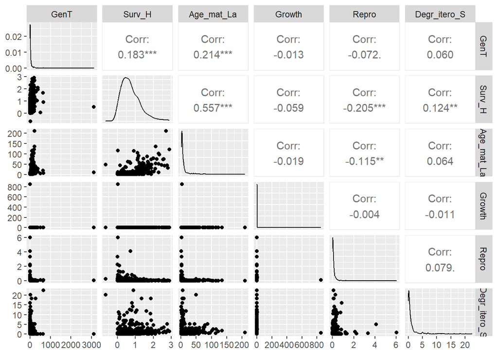

```r
ggpairs(non_missing_raw_data[LHT])
```

The data is largely not normal. But as mentionned in Capdevila et al. methods, the raw LHTs are log-transformed, scaled, and only 95% of data is kept before performing the PCA (to avoid extremums).

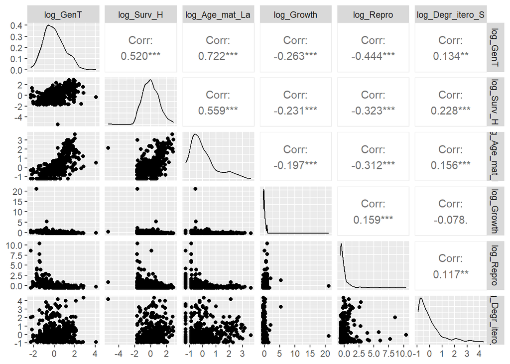

```r
#log transformation
non_missing_raw_data <- non_missing_raw_data %>%
                  mutate(across(LHT, ~ log(. + 1), .names = "log_{.col}"))

#standardisation = var to 1 and centered to 0
scale_funct <- function(x){
  (x - mean(x, na.rm=TRUE)) / sd(x, na.rm=TRUE)
}
non_missing_raw_data <- non_missing_raw_data %>%
                  mutate(across(paste0("log_",LHT), scale_funct))

#check distribution
ggpairs(non_missing_raw_data[paste0("log_",LHT)])
```

As in the original study, we need to extract the extreme values. Let’s choose 95% of species, but trying to adapt to the shape of distribution. It’s not exactly what have been done in the study where they took from 2.5th to 97.5th quantiles.

```r
#here split in several steps but objective is to filter the dataset with different values of percentile for each LHT
#filter conditions --> set according distribution curves. Keep 95% of the data
filter_conditions <- list(
  log_GenT = c(NA, 0.95),
  log_Surv_H = c(0.05, NA),
  log_Age_mat_La = c(NA, 0.95),
  log_Growth = c(NA, 0.95),
  log_Repro = c(NA, 0.95),
  log_Degr_itero_S = c(NA, 0.95))

#function to get the corresponding threshold value for each trait
values_quant <- c()
for (trait in paste0("log_",LHT)){
  cond <- filter_conditions[[trait]]
  lower <- if (!is.na(cond[1])) {quantile(non_missing_raw_data[[trait]], probs = cond[1], na.rm = TRUE)} else {NA}
  upper <- if (!is.na(cond[2])) {quantile(non_missing_raw_data[[trait]], probs = cond[2], na.rm = TRUE)} else {NA}
  values_quant[[trait]] <- c(lower,upper)
}

#creating the filtered data
filtered_data <- non_missing_raw_data %>%
  filter(across(paste0("log_", LHT), ~ {
    lower <- if (!is.na(unname(values_quant[[cur_column()]][1]))) {
      unname(values_quant[[cur_column()]][1])
    } else {
      min(., na.rm = TRUE)
    }
    upper <- if (!is.na(unname(values_quant[[cur_column()]][2]))) {
      unname(values_quant[[cur_column()]][2])
    } else {
      max(., na.rm = TRUE)
    }
    !is.na(.) & (. >= lower) & (. <= upper)
  }, .names = "filter_{col}")
)
```

### 3.1.3 PCA

From this dataset with non-missing data and transformed LHTs, we performed a PCA.

```r
#PCA
result_pca_filtered_data <- PCA(filtered_data[,paste0("log_", LHT)], scale.unit = TRUE, graph=FALSE)
```

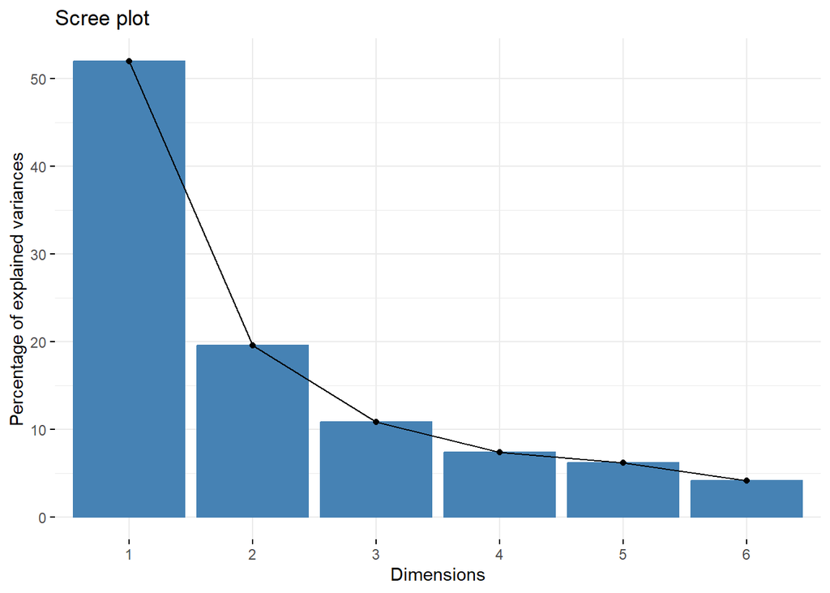

```r
#results exploration
fviz_eig(result_pca_filtered_data)
```

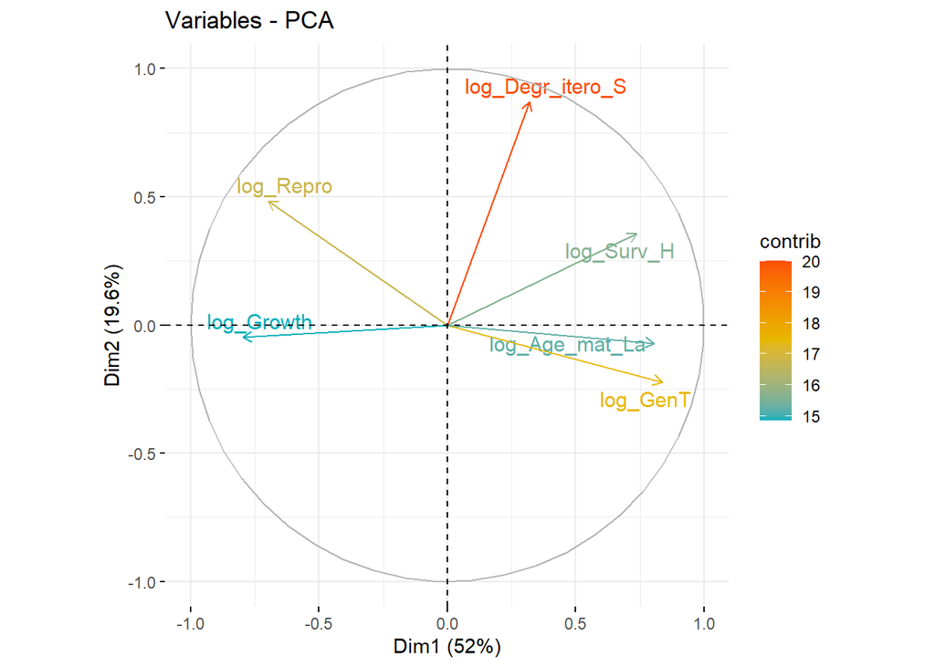

```r
fviz_pca_var(result_pca_filtered_data,
             col.var = "contrib",
             gradient.cols = c("#00AFBB", "#E7B800", "#FC4E07"),
             repel = TRUE)
```

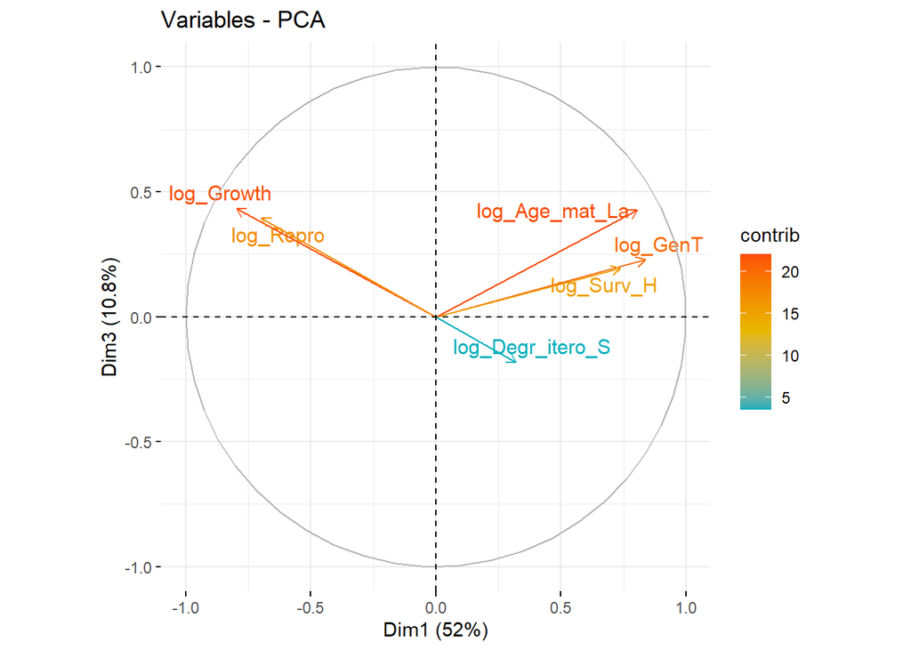

```r
fviz_pca_var(result_pca_filtered_data,
             axes=c(1,3),
             col.var = "contrib",
             gradient.cols = c("#00AFBB", "#E7B800", "#FC4E07"),
             repel = TRUE)
```

Same pattern as in the original PCA for the variance exaplined by the PC and the loadings of variables on the two PC1 and 2.

What about the organism type distribution in this PCA?

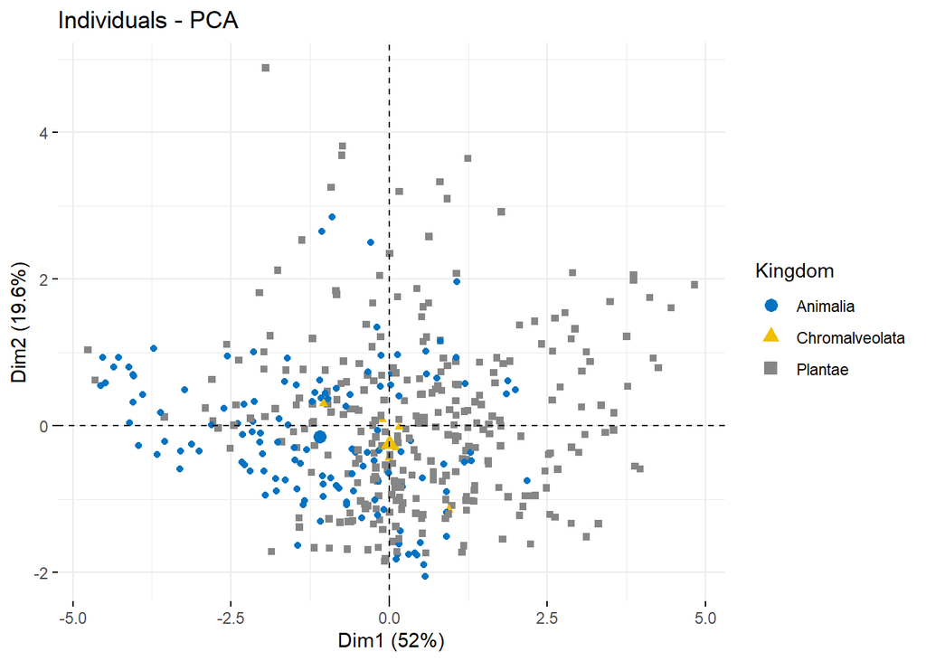

```r
fviz_pca_ind(result_pca_filtered_data,
             geom.ind = "point",
             col.ind = filtered_data$Kingdom,
             palette = "jco",
             addEllipses = FALSE,
             legend.title = "Kingdom")
```

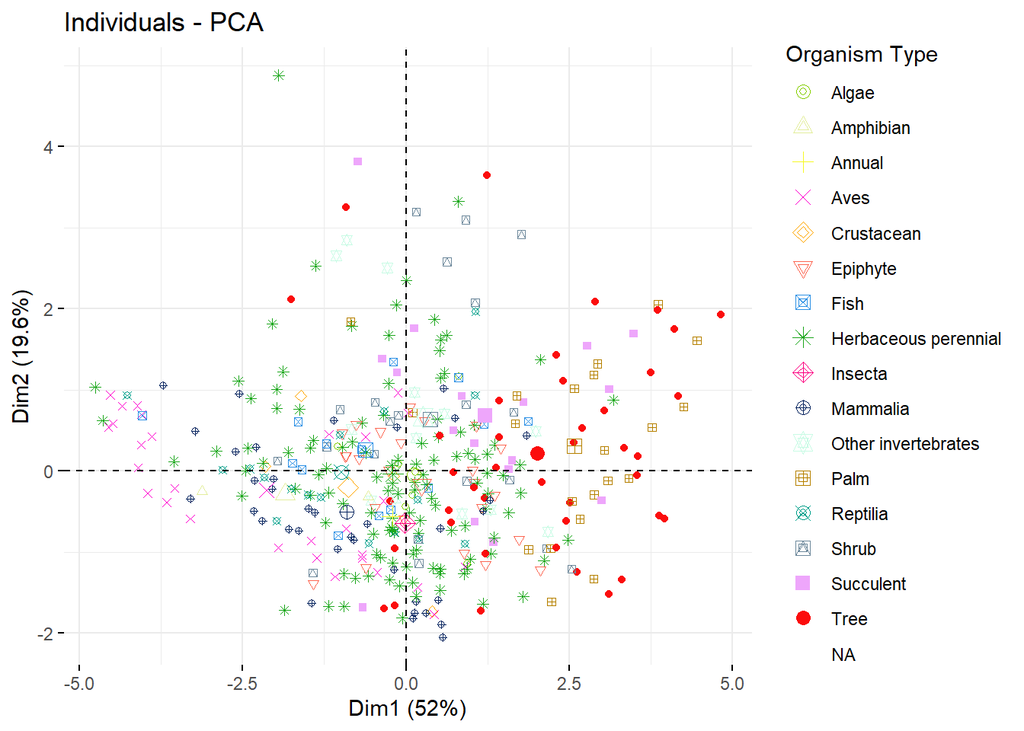

```r
fviz_pca_ind(result_pca_filtered_data,
             geom.ind = "point",
             col.ind = as.factor(filtered_data$OrganismType2),
             palette = colors_OrgType,
             label=filtered_data$Species,
             addEllipses = FALSE,
             legend.title = "Organism Type")
```

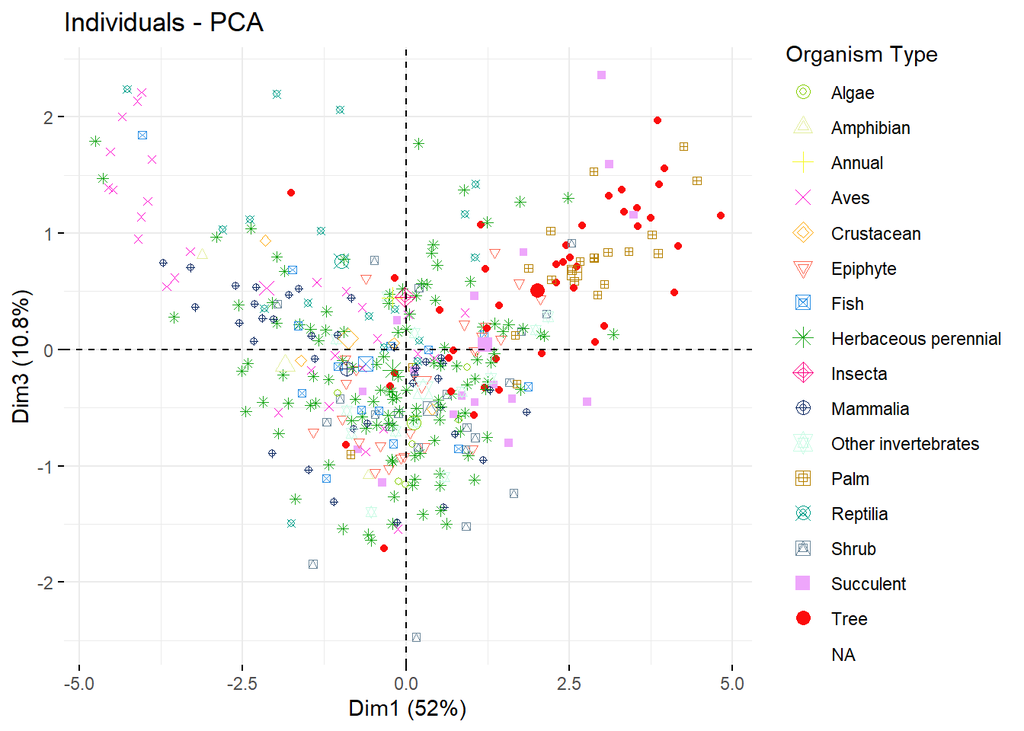

```r
fviz_pca_ind(result_pca_filtered_data,
             axes=c(1,3),
             geom.ind = "point",
             col.ind = as.factor(filtered_data$OrganismType2),
             palette = colors_OrgType,
             addEllipses = FALSE,
             legend.title = "Organism Type")
```

Keep the species coordinates in the PCA in a table:

```r
#get the dataset for individuals coordinates
coord_ind_unimputed_data <- get_pca_ind(result_pca_filtered_data)[["coord"]]
colnames(coord_ind_unimputed_data) <- paste0("PC",1:dim(get_pca_ind(result_pca_filtered_data)[["coord"]])[2],"_no_MD")
coord_ind_unimputed_data <- as.data.frame(coord_ind_unimputed_data)

# add the species name
coord_ind_unimputed_data <- coord_ind_unimputed_data %>%
  mutate(Species = filtered_data$Species) %>%
  relocate(Species, .before = 1)

head(coord_ind_unimputed_data)
```

|  | Species | PC1_no_MD | PC2_no_MD | PC3_no_MD | PC4_no_MD | PC5_no_MD |
| --- | --- | --- | --- | --- | --- | --- |
| 1 | Abies concolor | 2.4602814 | -0.6164383 | 0.8932495 | -0.25896136 | -0.43455212 |
| 2 | Abies magnifica | 2.5162136 | -0.3934907 | 0.7919460 | 0.06877091 | -0.33273615 |
| 3 | Abies sachalinensis | 1.4256563 | 0.4167400 | -0.3491616 | 0.11413450 | -0.05480939 |
| 4 | Acer pictum | 2.7022330 | 0.5267600 | 1.0657315 | -0.12655925 | -0.29001015 |
| 5 | Acer saccharum | -1.7623806 | 2.1181101 | 1.3488967 | 0.28172261 | -1.29984416 |
| 6 | Actaea cordifolia | -0.2094229 | -0.5828893 | -1.4973636 | 0.59620855 | 0.11622116 |

## 3.2 PCA from imputed data without phylogenetic correction

**In Capdevila et al. study, the PCA represented is in fact the mean PCA from 10 PCAs performed on 10 imputed datasets.** See in Capdevila et al. (2020) methods for more details about that.

We are going to use the imputed datasets published by the team to rerun PCAs on these datasets, without implementing a phylogenetic correction. For this, we adapted to our needs Capdevila et al. (2020) published code “PhylogeneticPCA.R”.

### 3.2.1 Load the 10 imputed datasets

Here are the 10 imputed datasets, published by the team.

```r
load("SalgoTeam_data/Capdevila_ImputedData.RData")
#as you can see two lists: terrestrial and aquatic
#each component of the list consists of a run from imputation
#10 runs have been performed

dem <- read.csv("SalgoTeam_data/LifeHistoryData.csv",sep=";")
# We also separate aquatic and terrestrial species like
ter <- subset(dem, R=="Terrestrial")
aq <- subset(dem, R=="Aquatic")

#rename the columns with the same LHT calling
ter <- ter %>% rename(GenT=GenT,
                      Surv_H=H,
                      Age_mat_La=La,
                      Growth=GrowSSD,
                      Repro=RepSSD,
                      Degr_itero_S=S)

aq <- aq %>% rename(GenT=GenT,
                    Surv_H=H,
                    Age_mat_La=La,
                    Growth=GrowSSD,
                    Repro=RepSSD,
                    Degr_itero_S=S)
```

### 3.2.2 PCAs

Now, let’s perform 10 PCAs on the 10 imputed datasets, without phylogenetic correction.

```r
colnames(Capdevila_raw_LHT_data)[1] <- "sp"
PCAscree <- PCAloadings <- PCAscore <- PCAEigen <-  list()

for (i in 1:length(ter)){

  ter[LHT] <- as.data.frame(imputed.terrestrial[[i]])
  aq[LHT] <- as.data.frame(imputed.aquatic[[i]])

  #Then we bind the two dataframes
  dem2 <- rbind(ter, aq)

  # MGH ADD --> the Organism type
  dem2 <- left_join(dem2,Capdevila_raw_LHT_data[,c(1,11)], by="sp")

  #We then join the numeric data that we will use for the pPCA
  Y <- dem2[LHT]

  # We need to give rownames as the species to do the pPCA
  row.names(Y) <- dem2$sp

  # We scale the data
  Y <- scale(Y)

  result <- PCA(Y, scale.unit=TRUE, ncp=ncol(Y), graph=FALSE)

  # The following inverts the order in which the PCA 1 axes (longevity)
  # will be displayed, so long-lived species are on the right

  if(result$var$coord["GenT","Dim.1"]<0){
    result$ind$coord[,"Dim.1"]=-result$ind$coord[,"Dim.1"]
    result$var$coord[,"Dim.1"]=-result$var$coord[,"Dim.1"]
    print(paste("invert PC1",i))
  }

  # Same as above but displaying highly reproductive species at the top

  if(result$var$coord["Degr_itero_S","Dim.2"]<0){
    result$ind$coord[,"Dim.2"]=-result$ind$coord[,"Dim.2"]
    result$var$coord[,"Dim.2"]=-result$var$coord[,"Dim.2"]
    print(paste("invert PC2",i))
  }

  #percent variance explained by each eigenvector

  percVar = result$eig[,2]
  names(percVar)=paste("PC",1:length(percVar))

  # Store the results

  PCAscree[[i]] <- percVar
  PCAscore[[i]] <- result$ind$coord
  PCAloadings[[i]] <- result$var$coord
  PCAEigen[[i]] <- result$eig

}

#cleaning
rm(aq, dem, dem2, imputed.aquatic, imputed.terrestrial, result, ter, Y, i)
```

We now are going to calculate the mean and standard deviation between these 10 PCAs for all the components of the PCA eg.for the variance explained by each principal component (PC), the LHTs loadings or the species coordinates, etc.

```r
# Proportion of variance explained by each PC
PCAscreeM <- apply(simplify2array(PCAscree), 1, mean)
PCAscreesd <- apply(simplify2array(PCAscree), 1, plotrix::std.error)
PCAscreMean<- cbind(PCAscreeM, PCAscreesd)

# Now for the individuals PC scores
PCAscoreM <- apply(simplify2array(PCAscore), 1:2, mean)
colnames(PCAscoreM) <- c("PC1","PC2","PC3","PC4","PC5","PC6")
PCAscoreM <- as.data.frame(PCAscoreM)
PCAscoreM$Species <- rownames(PCAscoreM)

PCAscorest <- apply(simplify2array(PCAscore),
                1:2,
                plotrix::std.error)
colnames(PCAscorest) <- c("PC1","PC2","PC3","PC4","PC5","PC6")
PCAscorest <- as.data.frame(PCAscorest)
PCAscorest$Species <- rownames(PCAscorest)

# The  traits loadings
PCALM <- apply(simplify2array(PCAloadings), 1:2, mean)
PCALst <- apply(simplify2array(PCAloadings),
                1:2,
                plotrix::std.error)

# Now the eigenvalues
PCAEigM <- apply(simplify2array(PCAEigen), 1:2, mean)
PCAEigst <- apply(simplify2array(PCAEigen),
                  1:2, plotrix::std.error)
```

### 3.2.3 Graphical representation of the “mean” PCA

Scree plot

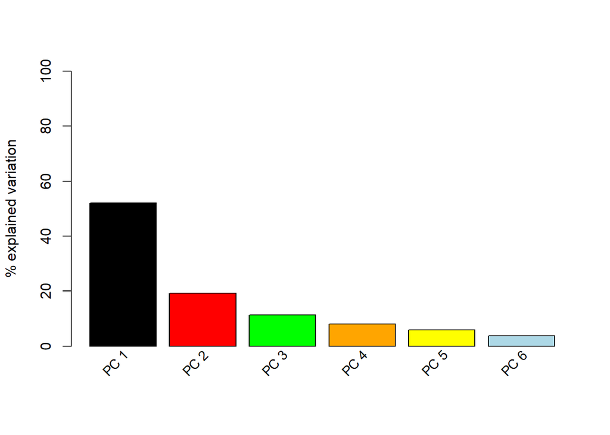

```r
mp=barplot(PCAscreMean[,1],ylab = "% explained variation",
           col=c("black","red","green","orange","yellow","light blue","purple","pink","maroon","blue2","blue"),
           ylim=c(0,100),axisnames=FALSE)
text(mp,par("usr")[3],
     labels = names(PCAscreMean[,1]),
     srt = 45, adj = c(1.1,1.1), xpd = TRUE, cex=.9)
```

Variables loadings

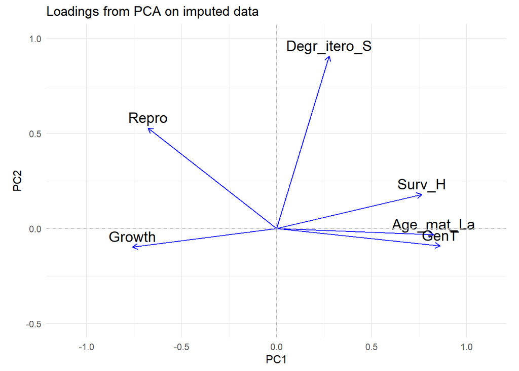

```r
#transform into a dataframe
PCALM <- as.data.frame(PCALM)
colnames(PCALM) <- paste0("Dim",1:ncol(PCALM),"_imp")
PCALM$Variables <- rownames(PCALM)

ggplot(PCALM, aes(x = Dim1_imp, y = Dim2_imp, label = Variables)) +
geom_segment(aes(x = 0, y = 0, xend = Dim1_imp, yend = Dim2_imp),
               arrow = arrow(length = unit(0.2, "cm")), color = "blue") +
  geom_text(hjust = 0.5, vjust = -0.5, size = 5) +
  theme_minimal() +
  labs(title = "Loadings from PCA on imputed data",
       x = "PC1",
       y = "PC2") +
  coord_fixed()+
  xlim(-1.1,1.1)+ylim(-0.5,1)+
  geom_hline(yintercept = 0, linetype = "dashed", color = "grey") +
  geom_vline(xintercept = 0, linetype = "dashed", color = "grey")
```

## 3.3 Comparison of the 3 PCAs

As a reminder the 3 PCAs to be compared are:  
- The original PCA from Capdevila et al. (2020) with both imputation and data and a phylogenetic correction - 807 species  
- A PCA with only inimputed data for the LHT - 553 species  
- A mean PCA from 10 imputed datasets (from Capdevila et al. 2020) and without phylogenetic correction - 807 species

### 3.3.1 Explained variance

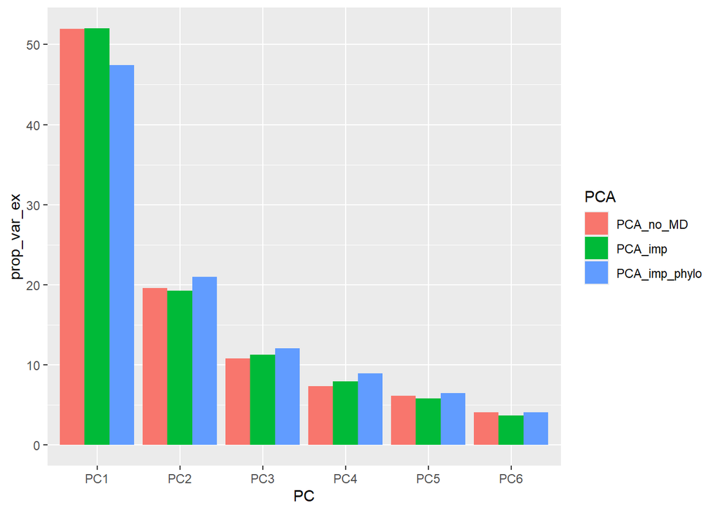

```r
# A tab with prop of cariance explained for each composant
prop_var_ex_PCAs <- data.frame(PCA_no_MD = result_pca_filtered_data$eig[,2],
                             PCA_imp = PCAEigM[,2],
                             PCA_imp_phylo = c(47.42,21.02,12.05,8.94,6.45,4.11))
prop_var_ex_PCAs$PC <- paste0("PC",1:dim(prop_var_ex_PCAs)[1])
prop_var_ex_PCAs <- prop_var_ex_PCAs %>%
                      pivot_longer(cols=c(1:3),
                                   names_to = "PCA",
                                   values_to = "prop_var_ex")

#barplot of this
prop_var_ex_PCAs$PCA <- factor(prop_var_ex_PCAs$PCA,
                               levels = c("PCA_no_MD", "PCA_imp", "PCA_imp_phylo"))
ggplot(prop_var_ex_PCAs, aes(x=PC,y=prop_var_ex, fill=PCA))+
  geom_bar(stat="identity", position=position_dodge())
```

Look at Table S2 for the loadings obtained with the different following PCAs.

### 3.3.2 Species coordinates

We will focus on the PC1-PC2 plane only.

First, store everything in a common dataset.

```r
colnames(Capdevila_raw_LHT_data)[1] <- "Species"

PCAscoreM <- left_join(PCAscoreM,Infos_species_Capdevila[,c("Species","OrganismType2","Imputation")], by="Species")
head(PCAscoreM)
```

|  | PC1 | PC2 | PC3 | PC4 | PC5 | PC6 | Species | OrganismType2 | Imputation |
| --- | --- | --- | --- | --- | --- | --- | --- | --- | --- |
| 1 | -0.4401632 | 0.28328379 | 0.3362735 | 0.19747278 | -0.01437689 | 0.01884796 | Abies balsamea | Tree | Yes |
| 2 | 2.0521724 | -0.62434685 | 0.5091156 | -0.11832876 | -0.43429518 | -0.23025198 | Abies concolor | Tree | No |
| 3 | 0.3861141 | -0.43118546 | 0.2462306 | 0.06925418 | 0.01068485 | -0.22610762 | Abies homolepis | Tree | Yes |
| 4 | 2.0755523 | -0.44887484 | 0.4349364 | -0.01176183 | -0.31650634 | -0.32857131 | Abies magnifica | Tree | No |
| 5 | 1.1626901 | 0.06245718 | -0.3566320 | -0.14768717 | -0.05642304 | -0.37711332 | Abies sachalinensis | Tree | No |
| 6 | -0.9368545 | -0.22265569 | -0.1120704 | 0.27438310 | 0.15604502 | -0.09348922 | Acacia aneura | Shrub | Yes |

```r
#a common dataset
coord_ind_PCAs <- Capdevila_2020_pl_ani %>%
  left_join(PCAscoreM, by= "Species", suffix = c("_imp_phylo","_imp"))

# add the other dataset
coord_ind_PCAs <- coord_ind_PCAs %>%
   left_join(coord_ind_unimputed_data, by= "Species")

coord_ind_PCAs <- coord_ind_PCAs %>%
                    select(Species,OrganismType2,Imputation, everything())

#dataset
head(coord_ind_PCAs)
```

|  | Species | OrganismType2 | Imputation | PC1_imp_phylo | PC2_imp_phylo | PC3_imp_phylo | PC4_imp_phylo | PC5_imp_phylo | PC6_imp_phylo | PC1_imp | PC2_imp | PC3_imp | PC4_imp | PC5_imp | PC6_imp | PC1_no_MD | PC2_no_MD | PC3_no_MD | PC4_no_MD | PC5_no_MD |
| --- | --- | --- | --- | --- | --- | --- | --- | --- | --- | --- | --- | --- | --- | --- | --- | --- | --- | --- | --- | --- |
| 1 | Abies balsamea | Tree | Yes | -0.7404187 | 0.2619532 | -0.3806717 | -0.21460466 | 0.003601952 | -0.03429793 | -0.4401632 | 0.28328379 | 0.3362735 | 0.19747278 | -0.01437689 | 0.01884796 | NA | NA | NA | NA | NA |
| 2 | Abies concolor | Tree | No | 1.8037040 | -0.4932003 | -0.3958398 | 0.04866753 | -0.404478963 | -0.29626292 | 2.0521724 | -0.62434685 | 0.5091156 | -0.11832876 | -0.43429518 | -0.23025198 | 2.460281 | -0.6164383 | 0.8932495 | -0.25896136 | -0.43455212 |
| 3 | Abies homolepis | Tree | Yes | 0.1287753 | -0.3892329 | -0.1050350 | 0.46744523 | 0.033444380 | -0.28155779 | 0.3861141 | -0.43118546 | 0.2462306 | 0.06925418 | 0.01068485 | -0.22610762 | NA | NA | NA | NA | NA |
| 4 | Abies magnifica | Tree | No | 1.8170242 | -0.3218674 | -0.3425488 | -0.09443416 | -0.287176991 | -0.38932467 | 2.0755523 | -0.44887484 | 0.4349364 | -0.01176183 | -0.31650634 | -0.32857131 | 2.516214 | -0.3934907 | 0.7919460 | 0.06877091 | -0.33273615 |
| 5 | Abies sachalinensis | Tree | No | 0.8956540 | 0.1267179 | 0.3165302 | 0.06984498 | -0.015507087 | -0.42217785 | 1.1626901 | 0.06245718 | -0.3566320 | -0.14768717 | -0.05642304 | -0.37711332 | 1.425656 | 0.4167400 | -0.3491616 | 0.11413450 | -0.05480939 |
| 6 | Acacia aneura | Shrub | Yes | -1.1942243 | -0.2745220 | 0.1037931 | -0.39158863 | 0.171870802 | -0.14536322 | -0.9368545 | -0.22265569 | -0.1120704 | 0.27438310 | 0.15604502 | -0.09348922 | NA | NA | NA | NA | NA |

Graphical representations:

- according to imputation

```r
i <- ggplot(coord_ind_PCAs, aes(x=PC1_no_MD, y=PC2_no_MD, color=Imputation, label=Species))+
  geom_point()+
  ggtitle("PCA with imputed data") +
  theme_bw(base_size = 16)
ggplotly(i)
```

[interactive chart not shown]

```r
i <- ggplot(coord_ind_PCAs, aes(x=PC1_imp, y=PC2_imp, color=Imputation, label=Species))+
  geom_point()+
  ggtitle("PCA with imputed data") +
  theme_bw(base_size = 16)
ggplotly(i)
```

[interactive chart not shown]

```r
i <- ggplot(coord_ind_PCAs, aes(x=PC1_imp_phylo, y=PC2_imp_phylo, color=Imputation, label=Species))+
  geom_point()+
  ggtitle("PCA with imputed + phylo corrected data") +
  theme_bw(base_size = 16)
ggplotly(i)
```

[interactive chart not shown]

- according to the organism type

```r
i <- ggplot(coord_ind_PCAs, aes(x=PC1_no_MD, y=PC2_no_MD, color=OrganismType2, label=Species))+
  geom_point()+
  scale_colour_manual(values=colors_OrgType, na.value = "grey") +
  ggtitle("PCA with unimputed data") +
  theme_bw(base_size = 16)
ggplotly(i)
```

[interactive chart not shown]

```r
i <- ggplot(coord_ind_PCAs, aes(x=PC1_imp, y=PC2_imp, color=OrganismType2, label=Species))+
  geom_point()+
  scale_colour_manual(values=colors_OrgType, na.value = "grey") +
  ggtitle("PCA with imputed data") +
  theme_bw(base_size = 16)
ggplotly(i)
```

[interactive chart not shown]

```r
i <- ggplot(coord_ind_PCAs, aes(x=PC1_imp_phylo, y=PC2_imp_phylo, color=OrganismType2, label=Species))+
  geom_point()+
  scale_colour_manual(values=colors_OrgType, na.value = "grey") +
  ggtitle("PCA with imputed + phylo corrected data - same as Capdevila et al. (2020), Fig 2") +
  theme_bw(base_size = 16)
ggplotly(i)
```

[interactive chart not shown]

Distribution of the variables across the first two PC:

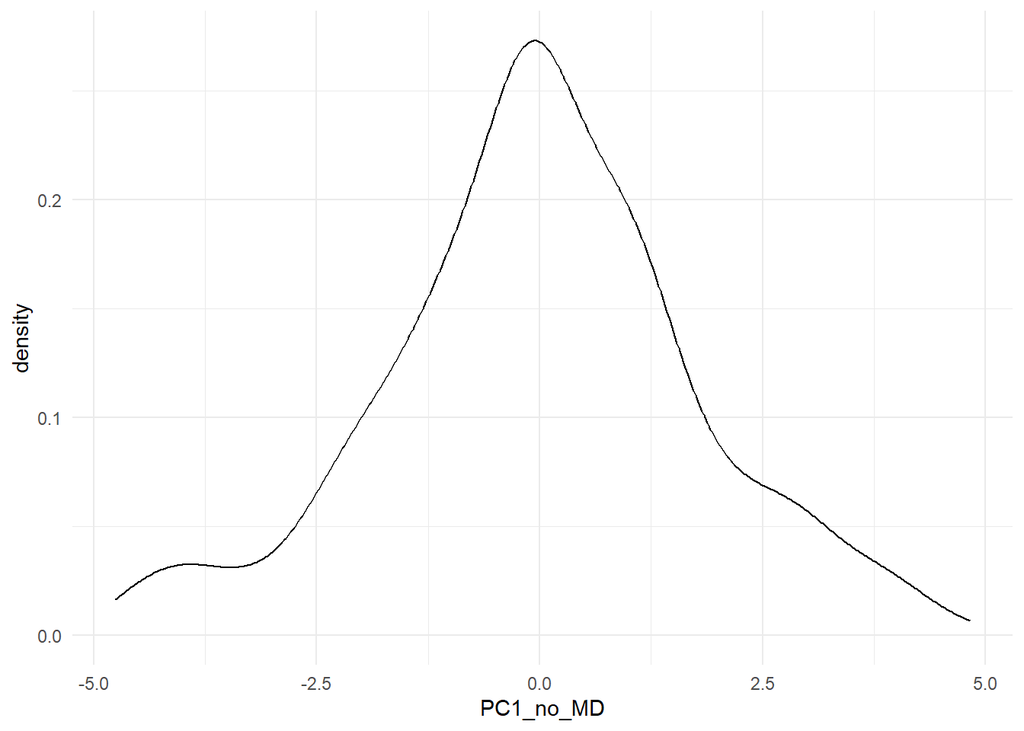

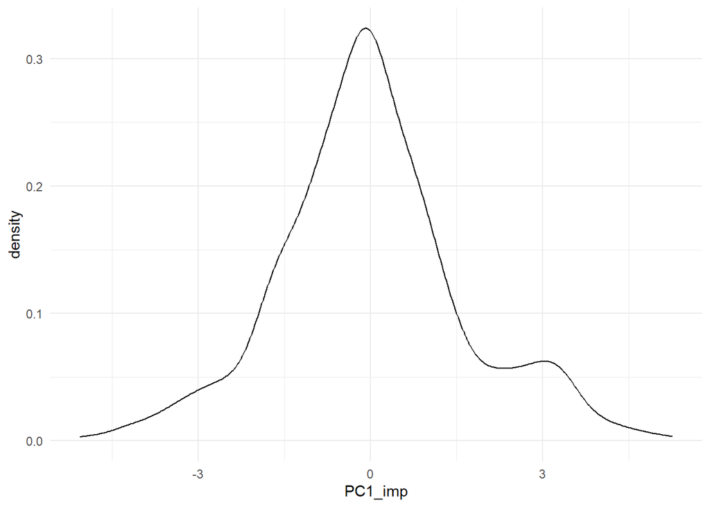

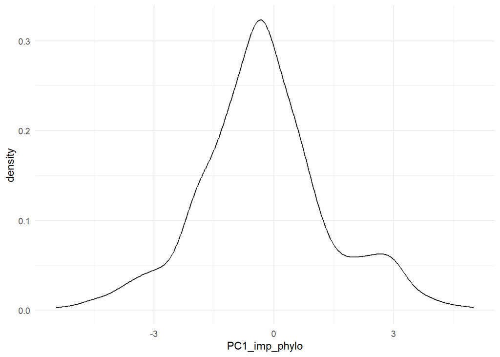

```r
#overall distribution curves
distribution_curve <- function(trait,dataset){
  ggplot(dataset) +
    geom_density(aes(x = !!sym(trait)), na.rm = TRUE) +
    theme_minimal()
}

#for PC1
map(c("PC1_no_MD","PC1_imp","PC1_imp_phylo"),distribution_curve,dataset=coord_ind_PCAs)
```

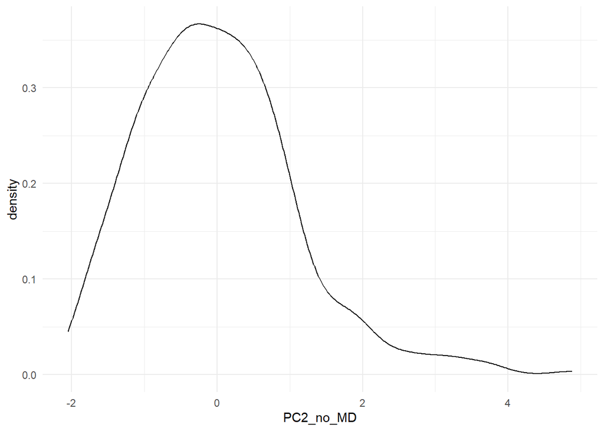

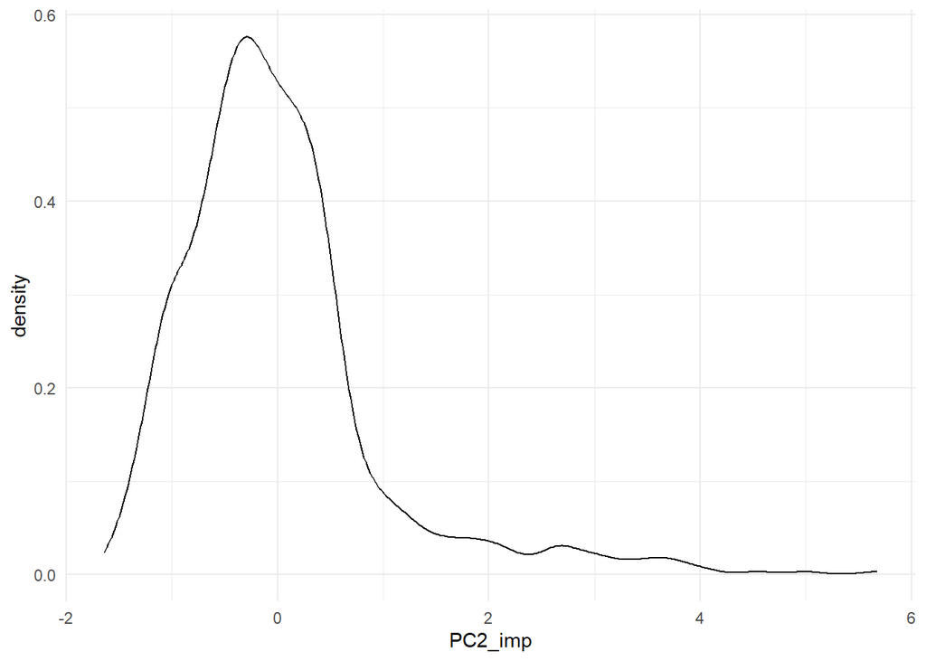

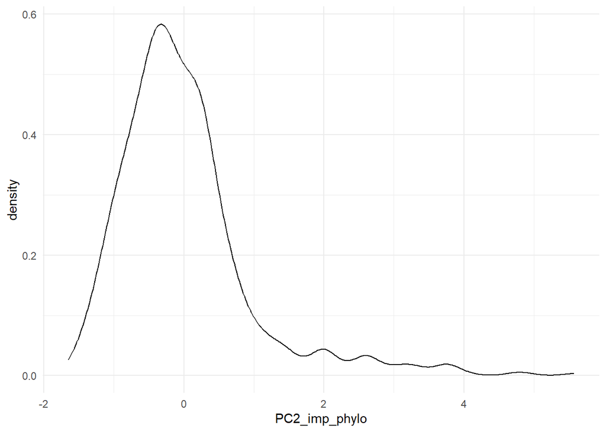

```r
#for PC2
map(c("PC2_no_MD","PC2_imp","PC2_imp_phylo"),distribution_curve,dataset=coord_ind_PCAs)
```

### 3.3.3 Figure S1 - correlation plots

#### 3.3.3.1 Effect of imputation

Correlation between umimputed data and imputed data. So this is for the 427 species with full data on LHT.

```r
#PC1
i <- ggplot(coord_ind_PCAs, aes(x=PC1_no_MD, y=PC1_imp, color=OrganismType2, label=Species))+
  geom_point()+
  geom_abline(slope = 1, intercept = 0, linetype = "dashed", color = "red") +
  geom_smooth(method = "lm", se = FALSE, color = "blue") +
  scale_colour_manual(values=colors_OrgType, na.value = "grey")
  ggtitle("PC1") +
  theme_bw(base_size = 16)
```

```r
ggplotly(i)
```

[interactive chart not shown]

```r
#PC2
i <- ggplot(coord_ind_PCAs, aes(x=PC2_no_MD, y=PC2_imp, color=OrganismType2, label=Species))+
  geom_point()+
  geom_abline(slope = 1, intercept = 0, linetype = "dashed", color = "red") +
  geom_smooth(method = "lm", se = FALSE, color = "blue") +
  scale_colour_manual(values=colors_OrgType, na.value = "grey")
  ggtitle("PC1") +
  theme_bw(base_size = 16)
```

```r
ggplotly(i)
```

[interactive chart not shown]

Checking the linear relation between the variables from the 2 PCAs:

```r
#PC1
summary(lm(PC1_no_MD~PC1_imp, data=coord_ind_PCAs))
```

```
##
## Call:
## lm(formula = PC1_no_MD ~ PC1_imp, data = coord_ind_PCAs)
##
## Residuals:
##       Min        1Q    Median        3Q       Max
## -0.268918 -0.038454  0.002151  0.039671  0.203202
##
## Coefficients:
##              Estimate Std. Error t value Pr(>|t|)
## (Intercept) -0.083335   0.003085  -27.01   <2e-16 ***
## PC1_imp      1.257523   0.002196  572.75   <2e-16 ***
## ---
## Signif. codes:  0 '***' 0.001 '**' 0.01 '*' 0.05 '.' 0.1 ' ' 1
##
## Residual standard error: 0.06368 on 425 degrees of freedom
##   (380 observations effacées parce que manquantes)
## Multiple R-squared:  0.9987, Adjusted R-squared:  0.9987
## F-statistic: 3.28e+05 on 1 and 425 DF,  p-value: < 2.2e-16
```

```r
#PC2
summary(lm(PC2_no_MD~PC2_imp, data=coord_ind_PCAs))
```

```
##
## Call:
## lm(formula = PC2_no_MD ~ PC2_imp, data = coord_ind_PCAs)
##
## Residuals:
##      Min       1Q   Median       3Q      Max
## -0.45488 -0.07638  0.01784  0.09002  0.54320
##
## Coefficients:
##             Estimate Std. Error t value Pr(>|t|)
## (Intercept) 0.343521   0.006835   50.26   <2e-16 ***
## PC2_imp     1.500841   0.009087  165.17   <2e-16 ***
## ---
## Signif. codes:  0 '***' 0.001 '**' 0.01 '*' 0.05 '.' 0.1 ' ' 1
##
## Residual standard error: 0.1346 on 425 degrees of freedom
##   (380 observations effacées parce que manquantes)
## Multiple R-squared:  0.9847, Adjusted R-squared:  0.9846
## F-statistic: 2.728e+04 on 1 and 425 DF,  p-value: < 2.2e-16
```

For both PC1 and PC2, the R2 > 0.98 So correlation is very good. Having imputed data in the PCA did not modify the position of species in the plan.

#### 3.3.3.2 Effect of phylogenetic correction

Let’s see in details for the two PCAs with imputed data and 807 species. Allow to see the effect of phylogenetic correction

```r
#PC1
i <- ggplot(coord_ind_PCAs, aes(x=PC1_imp_phylo, y=PC1_imp, color=OrganismType2, label=Species))+
  geom_point()+
  geom_abline(slope = 1, intercept = 0, linetype = "dashed", color = "red") +
  geom_smooth(method = "lm", se = FALSE, color = "blue") +
  scale_colour_manual(values=colors_OrgType, na.value = "grey")
  ggtitle("PC1") +
  theme_bw(base_size = 16)
```

```r
ggplotly(i)
```

[interactive chart not shown]

```r
#PC2
i <- ggplot(coord_ind_PCAs, aes(x=PC2_imp_phylo, y=PC2_imp, color=OrganismType2, label=Species))+
  geom_point()+
  geom_abline(slope = 1, intercept = 0, linetype = "dashed", color = "red") +
  geom_smooth(method = "lm", se = FALSE, color = "blue") +
  scale_colour_manual(values=colors_OrgType, na.value = "grey")
  ggtitle("PC1") +
  theme_bw(base_size = 16)
```

```r
ggplotly(i)
```

[interactive chart not shown]

Checking the linear relation between the variables from the 2 PCAs:

```r
#PC1
summary(lm(PC1_imp_phylo~PC1_imp, data=coord_ind_PCAs))
```

```
##
## Call:
## lm(formula = PC1_imp_phylo ~ PC1_imp, data = coord_ind_PCAs)
##
## Residuals:
##      Min       1Q   Median       3Q      Max
## -0.35080 -0.02204  0.01029  0.03677  0.09987
##
## Coefficients:
##              Estimate Std. Error t value Pr(>|t|)
## (Intercept) -0.271263   0.001969  -137.8   <2e-16 ***
## PC1_imp      0.996517   0.001213   821.2   <2e-16 ***
## ---
## Signif. codes:  0 '***' 0.001 '**' 0.01 '*' 0.05 '.' 0.1 ' ' 1
##
## Residual standard error: 0.05593 on 805 degrees of freedom
## Multiple R-squared:  0.9988, Adjusted R-squared:  0.9988
## F-statistic: 6.744e+05 on 1 and 805 DF,  p-value: < 2.2e-16
```

```r
#PC2
summary(lm(PC2_imp_phylo~PC2_imp, data=coord_ind_PCAs))
```

```
##
## Call:
## lm(formula = PC2_imp_phylo ~ PC2_imp, data = coord_ind_PCAs)
##
## Residuals:
##      Min       1Q   Median       3Q      Max
## -0.25633 -0.05293 -0.00847  0.04205  0.33781
##
## Coefficients:
##              Estimate Std. Error t value Pr(>|t|)
## (Intercept) -0.002163   0.003252  -0.665    0.506
## PC2_imp      0.997383   0.003379 295.156   <2e-16 ***
## ---
## Signif. codes:  0 '***' 0.001 '**' 0.01 '*' 0.05 '.' 0.1 ' ' 1
##
## Residual standard error: 0.09237 on 805 degrees of freedom
## Multiple R-squared:  0.9908, Adjusted R-squared:  0.9908
## F-statistic: 8.712e+04 on 1 and 805 DF,  p-value: < 2.2e-16
```

For both PC1 and PC2, the R2 > 0.99 So correlation is very good too. The phylogenetic correction in the PCA did not modify the position of species in the plan.

# 4 Comparison of species coordinates between two studies

To compare the relative position of species between the studies, we first need to select the common species. The PCA coordinates that I used were:  
- for Capdevila et al. 2020, provided upon request by Rob Salguero-Gomez  
- for Paniw et al. 2018, provided as a supplementary data in the related article.

```r
#loading Paniw et al. 2017 dataset - 449 plants and animals
Paniw_2017_plants_anim <- read.csv("SalgoTeam_data/Paniw&_2017_Temporal_autocorel_Sv1_PCA.csv")

Paniw_2017_plants_anim_coord_PCA <- Paniw_2017_plants_anim %>%
                                        select(species,PC1,PC2,habitat) %>%
                                        distinct()
rm(Paniw_2017_plants_anim)

head(Paniw_2017_plants_anim_coord_PCA)
```

|  | species | PC1 | PC2 | habitat |
| --- | --- | --- | --- | --- |
| 1 | Alaria_nana | -1.0803742 | 0.04108205 | Aquatic |
| 2 | Ascophyllum_nodosum_3 | -0.5941096 | -0.17710375 | Aquatic |
| 3 | Pterygophora_californica | -0.5141203 | 6.53557587 | Aquatic |
| 4 | Aeschynomene_virginica | -1.9528135 | -0.70057278 | Temperate |
| 5 | Brassica_napus_2 | -1.5903998 | 0.86231583 | Temperate |
| 6 | Collinsia_verna | -1.9024066 | -0.49268674 | Temperate |

## 4.1 Common species between the 2 studies

First, get the common species between the two studies.

```r
#Obj : get the common species between the 2 studies

## first have the same way of writing species names between the 2 studies
Paniw_2017_plants_anim_coord_PCA <- Paniw_2017_plants_anim_coord_PCA %>% mutate(Species= gsub("_", " ", species))
Paniw_2017_plants_anim_coord_PCA <- Paniw_2017_plants_anim_coord_PCA %>% mutate(Species= gsub(" [1-9]$", "", Species))

## intersection between species names
similar_species <- intersect(Paniw_2017_plants_anim_coord_PCA$Species,Capdevila_2020_pl_ani$Species)
head(similar_species)
```

```
## [1] "Alaria nana"              "Ascophyllum nodosum"
## [3] "Pterygophora californica" "Aeschynomene virginica"
## [5] "Collinsia verna"          "Catopsis compacta"
```

**Nb of common species**

```
## [1] 367
```

There are some adjustments to do in the dataframe

```r
subset_Paniw_2017 <- subset(Paniw_2017_plants_anim_coord_PCA, Species %in% similar_species)
subset_Capdevila_2020 <- subset(Capdevila_2020_pl_ani, Species %in% similar_species)

# 3 species in Paniw that have 2 populations data
table(subset_Paniw_2017$Species)[table(subset_Paniw_2017$Species) > 1]
```

```
##
##         Cirsium vulgare Mammillaria pectinifera     Panax quinquefolius
##                       2                       2                       2
```

```r
#Let's remove them by hand
subset_Paniw_2017 <- subset_Paniw_2017 %>% filter(!species %in% c("Cirsium_vulgare_3","Mammillaria_pectinifera_3","Panax_quinquefolius_3"))

#add info about the habitat in Capdevila
corres_spe_hab <- subset_Paniw_2017 %>% select(Species, habitat)

subset_Capdevila_2020 <- subset_Capdevila_2020 %>%
  left_join(corres_spe_hab, by = "Species")
```

Graphical representation of these common species

```r
#Graphical representation
## Paniw
i <-  ggplot(subset_Paniw_2017, aes(x=PC1, y=PC2, color=habitat, fill=habitat, label=Species))+
  geom_point() +
  ggtitle("Paniw - 2017")+
  theme_bw(base_size = 16)
ggplotly(i)
```

[interactive chart not shown]

```r
## Capdevila
j <- ggplot(subset_Capdevila_2020, aes(x=PC1, y=PC2, color=habitat, fill=habitat, label=Species))+
  geom_point() +
  ggtitle("Capdevila - 2020")+
  theme_bw(base_size = 16)
ggplotly(j)
```

[interactive chart not shown]

## 4.2 Correlations of species coordinates for the first two PC between the studies

Correlation between PC1 results for Paniw and Capdevila studies:

```r
cor(coord_PCA_com$PC1_Capdevila, coord_PCA_com$PC1_Paniw, method="pearson")
```

```
## [1] 0.8306535
```

```r
cor(coord_PCA_com$PC1_Capdevila, coord_PCA_com$PC1_Paniw, method="spearman")
```

```
## [1] 0.7864611
```

Checking the linear relation between the 2 variables:

```r
summary(lm(PC1_Capdevila~PC1_Paniw, data=coord_PCA_com))
```

```
##
## Call:
## lm(formula = PC1_Capdevila ~ PC1_Paniw, data = coord_PCA_com)
##
## Residuals:
##     Min      1Q  Median      3Q     Max
## -4.2916 -0.4545  0.0819  0.5338  2.3890
##
## Coefficients:
##             Estimate Std. Error t value Pr(>|t|)
## (Intercept)  0.14284    0.04520    3.16  0.00171 **
## PC1_Paniw    1.26419    0.04435   28.50  < 2e-16 ***
## ---
## Signif. codes:  0 '***' 0.001 '**' 0.01 '*' 0.05 '.' 0.1 ' ' 1
##
## Residual standard error: 0.8657 on 365 degrees of freedom
## Multiple R-squared:   0.69,  Adjusted R-squared:  0.6891
## F-statistic: 812.4 on 1 and 365 DF,  p-value: < 2.2e-16
```

Quite a good correlation, in particular for PC1. Let’s represent this on a graph with a regression line

First, for the PC1 –> related to generation time, rate of senescence, age at maturity, growth and mean sexual reproduction

```r
i <- ggplot(coord_PCA_com, aes(x=PC1_Capdevila, y=PC1_Paniw, color=habitat_Paniw, label=Species))+
  geom_point()+
  geom_abline(slope = 1, intercept = 0, linetype = "dashed", color = "red") +
  geom_smooth(method = "lm", se = FALSE, color = "blue") +
  ggtitle("PC1") +
  theme_bw(base_size = 16)
ggplotly(i)
```

[interactive chart not shown]

*in blue, linear regression / in red, x=y*

For the PC2, related to Mean sexual reproduction and Degree of iteroparity.

Correlation between PC2 results for Paniw and Capdevila studies:

```r
cor(coord_PCA_com$PC2_Capdevila, coord_PCA_com$PC2_Paniw, method="pearson")
```

```
## [1] 0.6493267
```

```r
cor(coord_PCA_com$PC2_Capdevila, coord_PCA_com$PC2_Paniw, method="spearman")
```

```
## [1] 0.674987
```

Checking the linear relation between the 2 variables:

```r
summary(lm(PC2_Capdevila~PC2_Paniw, data=coord_PCA_com))
```

```
##
## Call:
## lm(formula = PC2_Capdevila ~ PC2_Paniw, data = coord_PCA_com)
##
## Residuals:
##     Min      1Q  Median      3Q     Max
## -5.3357 -0.4511 -0.1174  0.3148  6.1593
##
## Coefficients:
##             Estimate Std. Error t value Pr(>|t|)
## (Intercept)  0.07518    0.04265   1.763   0.0788 .
## PC2_Paniw    0.68286    0.04186  16.312   <2e-16 ***
## ---
## Signif. codes:  0 '***' 0.001 '**' 0.01 '*' 0.05 '.' 0.1 ' ' 1
##
## Residual standard error: 0.8169 on 365 degrees of freedom
## Multiple R-squared:  0.4216, Adjusted R-squared:   0.42
## F-statistic: 266.1 on 1 and 365 DF,  p-value: < 2.2e-16
```

Graphical representation:

```r
i <- ggplot(coord_PCA_com, aes(x=PC2_Capdevila, y=PC2_Paniw, color=habitat_Paniw, label=Species))+
  geom_point()+
  geom_abline(slope = 1, intercept = 0, linetype = "dashed", color = "red") +
  geom_smooth(method = "lm", se = FALSE, color = "blue") +
  ggtitle("PC2") +
  theme_bw(base_size = 16)
ggplotly(i)
```

[interactive chart not shown]

*in blue, linear regression / in red, x=y*

# 5 Implementation of the LHT variation plane categorizing framework

Given the robustness of the species coordinates in the LHT variation plane within PC1 and PC2 plan, we will use that to build a categorizing framework made of two principal axes: the Fast-slow continuum and Reproductive Strategies continuum. To do so, we will use the coordinates of species in the PCA with imputed data and phylogenetic correction from Capdevila et al. (2020) study.

First, axes bounds will be set to -1 and 1 respectively, with 95% of the species being retained within those bounds. We will then delimit three ranges of values along each axis: FastFS, IntermFS and SlowFS along the FS continuum, and LowRS, IntermRS and HighRS along the RS continuum, resulting in nine categories when combined.

## 5.1 Standardization of data

For PC1 and PC2, from the two sets of data, I will create “normalized” data, in details:  
- for PC1, values above and under 2.5th and 97.5th quantiles  
- for PC2, values under 95th quantile (see the distribution of the variable above)  
- transformation of the variables to have value between -1 and 1

Values of the thresholds that will be used, selecting 95% of species within a given axis:

```r
#Phylo corrected PCA
quantile_PC1_imp_phylo <- quantile(coord_ind_PCAs$PC1_imp_phylo, probs = c(0.025, 0.975))
quantile_PC2_imp_phylo <- quantile(coord_ind_PCAs$PC2_imp_phylo, probs = 0.95)

#imputed data PCA
quantile_PC1_imp <- quantile(coord_ind_PCAs$PC1_imp, probs = c(0.025, 0.975))
quantile_PC2_imp <- quantile(coord_ind_PCAs$PC2_imp, probs = 0.95)
```

Normalisation of data:

```r
#Function to have the values between -1 and 1
normalize_to_range <- function(x, new_min = -1, new_max = 1, old_min, old_max) {
  #old_min <- min(x, na.rm = TRUE)
  #old_max <- max(x, na.rm = TRUE)
  scaled_x <- (new_max - new_min) * (x - old_min) / (old_max - old_min) + new_min
  return(scaled_x)
}

#Normalise the PC1 and PC2 values
coord_ind_PCAs <- coord_ind_PCAs %>%
  mutate(#for PC1 of the two PCA
    PC1_norm_imp_phylo = case_when(
    PC1_imp_phylo < quantile_PC1_imp_phylo[1] ~ -1, #if an extremum, value of -1 directly
    PC1_imp_phylo > quantile_PC1_imp_phylo[2] ~ 1, #if an extremum, value of 1 directly
    TRUE ~ normalize_to_range(PC1_imp_phylo,old_min=quantile_PC1_imp_phylo[1],old_max=quantile_PC1_imp_phylo[2])),

    PC1_norm_imp = case_when(
    PC1_imp < quantile_PC1_imp[1] ~ -1,
    PC1_imp > quantile_PC1_imp[2] ~ 1,
    TRUE ~ normalize_to_range(PC1_imp, old_min=quantile_PC1_imp[1],old_max=quantile_PC1_imp[2])),

    #for PC2
    PC2_norm_imp_phylo = case_when(
    PC2_imp_phylo > quantile_PC2_imp_phylo[1] ~ 1,
    TRUE ~ normalize_to_range(PC2_imp_phylo,old_min=min(PC2_imp_phylo),old_max=quantile_PC2_imp_phylo[1])),

    PC2_norm_imp = case_when(
    PC2_imp > quantile_PC2_imp[1] ~ 1,
    TRUE ~ normalize_to_range(PC2_imp, old_min=min(PC2_imp),old_max=quantile_PC2_imp[1]))
    )
```

## 5.2 Figure S2A - Species assignment across categories

Spread of Capdevila et al. (2020) set of 807 species within the three ranges of values along each axis:

```r
#to split our plan in 9 subsquares
breaks <- seq(-1, 1, length.out = 4)

i <- coord_ind_PCAs %>% filter(!Species %in% missing_data$Species) %>%
  ggplot(aes(x=PC1_norm_imp_phylo, y=PC2_norm_imp_phylo, color=OrganismType2, shape=OrganismType2, label=Species))+
  geom_point()+
  theme_minimal()+
  scale_color_manual(values=colors_OrgType, na.value = "grey")+
  scale_shape_manual(values=shape_OrgType, na.value = 16)+
  scale_x_continuous(limits = c(-1, 1), breaks = breaks, labels=round(breaks, 2)) +
  scale_y_continuous(limits = c(-1, 1), breaks = breaks, labels=round(breaks, 2)) +
  geom_vline(xintercept = breaks, color = "black", linetype = "dashed") +
  geom_hline(yintercept = breaks, color = "black", linetype = "dashed")
ggplotly(i)
```

[interactive chart not shown]

## 5.3 Figure S2B - LHT values according to the LHT categories

For each of the nine categories (define through the three ranges of values along each axis), here are the spread of the 6 LHTs for non imputed data:

```r
extract_species <- function(pc1_min, pc1_max, pc2_min, pc2_max) {
  coord_ind_PCAs %>%
    filter(
      !Species %in% missing_data$Species,
      PC1_norm_imp_phylo >= pc1_min & PC1_norm_imp_phylo <= pc1_max,
      PC2_norm_imp_phylo >= pc2_min & PC2_norm_imp_phylo <= pc2_max
    ) %>%
    pull(Species)
}

species_by_subsquare <- list(fast_low_S=extract_species(-1,-0.33,-1,-0.33),
                             fast_interm_S=extract_species(-1,-0.33,-0.33,0.33),
                             fast_high_S=extract_species(-1,-0.33,0.33,1),

                             interm_low_S=extract_species(-0.33,0.33,-1,-0.33),
                             center=extract_species(-0.33,0.33,-0.33,0.33),
                             interm_high_S=extract_species(-0.33,0.33,0.33,1),

                             slow_low_S=extract_species(0.33,1,-1,-0.33),
                             slow_interm_S=extract_species(0.33,1,-0.33,0.33),
                             slow_high_S=extract_species(0.33,1,0.33,1))

#check if it's okay
sum(sapply(species_by_subsquare, length))
```

```
## [1] 553
```

As expected, we found the 553 rows of species with unimputed LHT data.

Plot this as a boxplot for each LHT and each category:

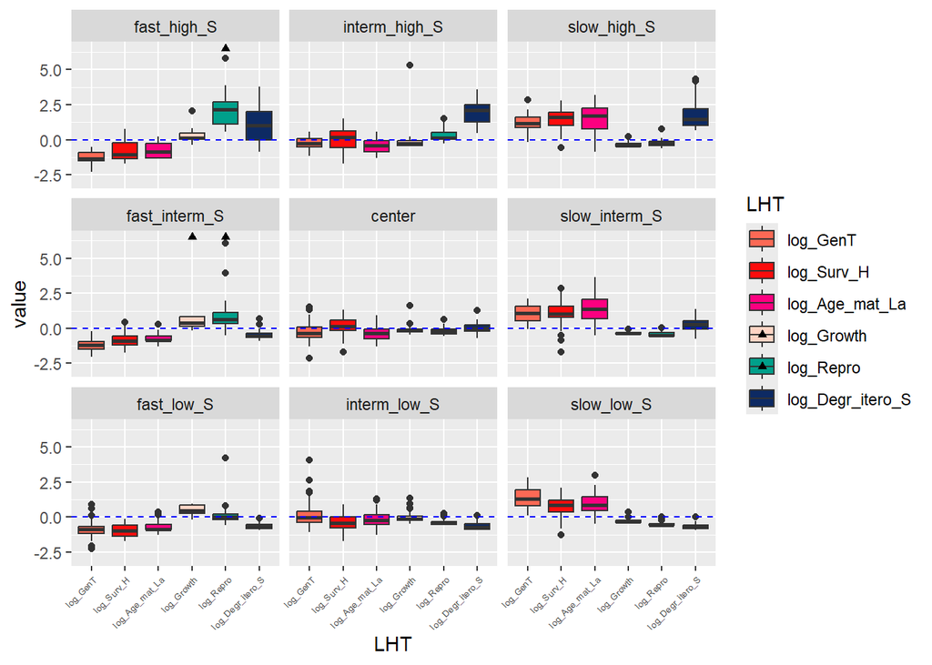

```r
#prepare the dataframe for the figure
values_by_catego <- lapply(species_by_subsquare,function(x){
  non_missing_raw_data %>% filter(Species %in% x)} %>%
    select(LHT,paste0("log_",LHT)))

values_by_catego <- bind_rows(values_by_catego, .id = "Subsquare")

values_by_catego <- values_by_catego %>%
                                  pivot_longer(cols=-Subsquare,
                            names_to = "LHT")

#let's order the subsquare, here, first the fast species, the interm column and then the slow species
values_by_catego$Subsquare <- factor(values_by_catego$Subsquare,
                                                   levels=c("fast_high_S","interm_high_S","slow_high_S",
                                                            "fast_interm_S","center","slow_interm_S",
                                                            "fast_low_S","interm_low_S","slow_low_S"))

#order the LHT
values_by_catego$LHT <- factor(values_by_catego$LHT,
                                                   levels=c(paste0("log_",LHT),LHT))

#plot the graphic
values_by_catego %>% filter(LHT %in% paste0("log_",LHT)) %>%
  ggplot(aes(x=LHT,y=value,fill=LHT))+
  geom_boxplot()+
  geom_point(data = . %>% filter(value > 6.5),
             aes(y = 6.5),
             shape = 17,
             color = "black") +
  theme(axis.text.x = element_text(angle = 45, hjust = 1, size=5))+
  scale_fill_manual(values=c("#FC6955FF","#FB0D0DFF","#FC0080FF","#FED4C4FF","#00A08BFF","#0D2A63FF"))+
  ylim(c(-3,6.5))+
  geom_hline(yintercept = 0, color = "blue", linetype = "dashed")+
  facet_wrap(~Subsquare)
```